# AIC Analysis Q1

Elizabeth Max

#Set up

```r
rm(list=ls())

#AIC
library(AICcmodavg)
library(plm) #for random factors
library(lme4)
library(car)

#Table
library(sjPlot)
library(sjmisc)
library(sjlabelled)
library(insight)
library(tibble)
library(gridExtra)

#extra, just in case
library(tidyverse)
library(ggpubr)
library(scales)
library(chron)
library(plotly)
library(aweek)
library(easypackages)
library(renv)
library(here)
library(ggthemes)
library(gridExtra)
library(patchwork)
library(tidyquant)
library(recipes)
library(cranlogs)
library(knitr)
library(openair)
library(xts)
library(dplyr)
library(reshape2)
```

Set work drive and upload csv

```r
#Set work drive
setwd("C:/Users/Elizabeth Max/iCloudDrive/Thesis/Data/R")
#upload file
masterfile <- read.csv("masterfile3.csv")
```

Combine columns by cover type

```r
#all crusting species
masterfile$crusting <-
  masterfile$Aplidium.californicum +
  masterfile$Aplysilla.glacialis +
  masterfile$Archidistoma.ritteri +
  masterfile$bryozoan +
  masterfile$crustose.coralline. +
  masterfile$Didemnum.carnulentum +
  masterfile$Halichondria.sp_ +
  masterfile$Haliclona.spp. +
  masterfile$Hildenbrandia.spp. +
  masterfile$Higginsia.sp_ +
  masterfile$hydrozoans..brown. +
  masterfile$Ophlitaspongia.pennata +
  masterfile$Petrocelis.phase. +
  masterfile$Petrospongium.rugosum +
  masterfile$Peyssonnelia.sp_ +
  masterfile$Phragmatopoma.californica +
  masterfile$Porifera.spp. +
  masterfile$Spirorbis.borealis
```

```r
#all upright species
masterfile$upright <-
  masterfile$Ahnfeltiopsis.linearis +
  masterfile$Alaria.marginata +
  masterfile$Anthopleura.elegantissima +
  masterfile$Anthopleura.xanthogrammica +
  masterfile$Balanus.spp. +
  masterfile$blue.green.algae +
  masterfile$Bornetia.californica +
  masterfile$Bossiella.plumosa +
  masterfile$Bossiella.schmittii. +
  masterfile$Bryopsis.corticulans +
  masterfile$Calliarthron.tuberculosum +
  masterfile$Callithamnion.pikeanum +
  masterfile$Callophyllis.sp_ +
  masterfile$Corallina.eatoniana. +
  masterfile$Chondracanthus.canaliculatus +
  masterfile$Chondracanthus.spinosus +
  masterfile$Cladophora.columbiana +
  masterfile$Cladophora.graminea +
  masterfile$Cladophora.sp_ +
  masterfile$Colpomenia.peregrina +
  masterfile$Corallina.vancouveriensis. +
  masterfile$Crepipatella.lingulata +
  masterfile$Cryptopleura.spp +
  masterfile$Cyanobacteria +
  masterfile$diatom +
  masterfile$Dilsea.californica +
  masterfile$Egregia.menziesii +
  masterfile$Endocladia.muricata +
  masterfile$Erythrophyllum.delesseriodes +
  masterfile$Farlowia.mollis +
  masterfile$Gelidium.spp. +
  masterfile$Grateloupia.angusta +
  masterfile$Grateloupia.cornea +
  masterfile$Hymenena.flabelligera +
  masterfile$Katharina.tunicata +
  masterfile$Lacuna.spp. +
  masterfile$Leathesia.spp. +
  masterfile$Lepidochitona.dentiens +
  masterfile$Leptasterias.spp. +
  masterfile$Littorina.keenae. +
  masterfile$Littorina.planaxis +
  masterfile$Littorina.scutulata +
  masterfile$Littorina.sitkana +
  masterfile$Lottia.digitalis +
  masterfile$Lottia.gigantea +
  masterfile$Lottia.pelta +
  masterfile$Lottia.scabra +
  masterfile$Lottia.sp_ +
  masterfile$Lottia.strigatella +
  masterfile$Maripelta.rotata +
  masterfile$Mastocarpus.jardinii +
  masterfile$Mastocarpus.papillatus+
  masterfile$Mastocarpus.sp_ +
  masterfile$Mazzaella.affinis +
  masterfile$Mazzaella.californica +
  masterfile$Mazzaella.flaccida +
  masterfile$Mazzaella.oregona +
  masterfile$Mazzaella.parksii +
  masterfile$Mazzaella.splendens +
  masterfile$Microcladia.borealis +
  masterfile$Microcladia.coulteri +
  masterfile$Mopalia.ciliata +
  masterfile$Mopalia.muscosa +
  masterfile$Musculus.pygmaeus +
  masterfile$Myriogramme.variegata +
  masterfile$Mytilus.californianus. +
  masterfile$Neogastroclonium.subarticulatum +
  masterfile$Neoptilota.hypnoides +
  masterfile$Neorhodomela.larix +
  masterfile$Nienburgia.sp_ +
  masterfile$Notoacmea.insessa +
  masterfile$Notoacmea.persona +
  masterfile$Nucella.canaliculata +
  masterfile$Nucella.emarginata +
  masterfile$Nucella.sp_ +
  masterfile$Nuttallina.californica +
  masterfile$Odonthalia.floccosa +
  masterfile$Opuntiella.californica +
  masterfile$Osmundea.spectabilis +
  masterfile$Phyllochaetopterus.prolifica +
  masterfile$Phyllospadix.scouleri +
  masterfile$Plocamium.spp. +
  masterfile$Pollicipes.polymerus +
  masterfile$Polyneura.latissima +
  masterfile$Polysiphonia.hendryi +
  masterfile$Polysiphonia.pacifica +
  masterfile$Polysiphonia.savatieri +
  masterfile$Porphyra.spp. +
  masterfile$Prasiola.sp_ +
  masterfile$Prionitis.lanceolata +
  masterfile$Prionitis.sternbergii +
  masterfile$Prionitis.sp. +
  masterfile$Pterocladia.capillacea +
  masterfile$Pterocladiella.caloglossoides +
  masterfile$Rhodymenia.californica +
  masterfile$Rhodymenia.pacifica +
  masterfile$Rhodymenia.sp_ +
  masterfile$Scytosiphon.lomentaria +
  masterfile$Semibalanus.cariosus +
  masterfile$Semibalanus.sp_ +
  masterfile$Serpula.sp_ +
  masterfile$Tegula.brunnea +
  masterfile$Tegula.funebralis +
  masterfile$Tethya.aurantium +
  masterfile$Tetraclita.rubescens +
  masterfile$Tonicella.lineata +
  masterfile$Trimusculus.reticulatus +
  masterfile$tropical.green +
  masterfile$tunicate +
  masterfile$Ulothrix.flacca +
  masterfile$Ulva.spp. +
  masterfile$Weeksia.reticulata
```

```r
#upright algae
masterfile$upalgae <-
  masterfile$Ahnfeltiopsis.linearis +
  masterfile$Alaria.marginata +
  masterfile$blue.green.algae +
  masterfile$Bornetia.californica +
  masterfile$Bossiella.plumosa +
  masterfile$Bossiella.schmittii. +
  masterfile$Bryopsis.corticulans +
  masterfile$Calliarthron.tuberculosum +
  masterfile$Callithamnion.pikeanum +
  masterfile$Callophyllis.sp_ +
  masterfile$Chondracanthus.canaliculatus +
  masterfile$Chondracanthus.spinosus +
  masterfile$Cladophora.columbiana +
  masterfile$Cladophora.graminea +
  masterfile$Cladophora.sp_ +
  masterfile$Colpomenia.peregrina +
  masterfile$Corallina.eatoniana. +
  masterfile$Corallina.vancouveriensis. +
  masterfile$Cryptopleura.spp +
  masterfile$Cyanobacteria +
  masterfile$diatom +
  masterfile$Dilsea.californica +
  masterfile$Egregia.menziesii +
  masterfile$Endocladia.muricata +
  masterfile$Erythrophyllum.delesseriodes +
  masterfile$Farlowia.mollis +
  masterfile$Gelidium.spp. +
  masterfile$Grateloupia.angusta +
  masterfile$Grateloupia.cornea +
  masterfile$Hymenena.flabelligera +
  masterfile$Leathesia.spp.+
  masterfile$Maripelta.rotata +
  masterfile$Mastocarpus.jardinii +
  masterfile$Mastocarpus.papillatus +
  masterfile$Mastocarpus.sp_ +
  masterfile$Mazzaella.affinis +
  masterfile$Mazzaella.californica +
  masterfile$Mazzaella.flaccida +
  masterfile$Mazzaella.oregona +
  masterfile$Mazzaella.parksii
  masterfile$Mazzaella.splendens +
  masterfile$Microcladia.borealis +
  masterfile$Microcladia.coulteri +
  masterfile$Myriogramme.variegata +
  masterfile$Neogastroclonium.subarticulatum +
  masterfile$Neoptilota.hypnoides +
  masterfile$Neorhodomela.larix +
  masterfile$Nienburgia.sp_ +
  masterfile$Odonthalia.floccosa +
  masterfile$Opuntiella.californica +
  masterfile$Osmundea.spectabilis +
  masterfile$Phyllospadix.scouleri +
  masterfile$Plocamium.spp. +
  masterfile$Polyneura.latissima +
  masterfile$Polysiphonia.hendryi +
  masterfile$Polysiphonia.pacifica +
  masterfile$Polysiphonia.savatieri +
  masterfile$Porphyra.spp. +
  masterfile$Prasiola.sp_ +
  masterfile$Prionitis.lyallii +
  masterfile$Prionitis.sternbergii +
  masterfile$Prionitis.sp. +
  masterfile$Pterocladia.caloglossoides +
  masterfile$Pterocladia.capillacea +
  masterfile$Rhodymenia.californica +
  masterfile$Rhodymenia.pacifica +
  masterfile$Rhodymenia.sp_ +
  masterfile$Scytosiphon.lomentaria +
  masterfile$tropical.green +
  masterfile$Ulothrix.flacca +
  masterfile$Ulva.spp.+
  masterfile$Weeksia.reticulata
```

```
## integer(0)
```

```r
#all upright invertebrates
masterfile$upinverts <-
  masterfile$tunicate +
  masterfile$Trimusculus.reticulatus +
  masterfile$Tonicella.lineata +
  masterfile$Tetraclita.rubescens +
  masterfile$Tethya.aurantium +
  masterfile$Tegula.funebralis +
  masterfile$Tegula.brunnea +
  masterfile$Semibalanus.cariosus +
  masterfile$Semibalanus.sp_ +
  masterfile$Serpula.sp_ +
  masterfile$Pollicipes.polymerus +
  masterfile$Phyllochaetopterus.prolifica +
  masterfile$Nucella.canaliculata +
  masterfile$Nucella.emarginata +
  masterfile$Nucella.sp_ +
  masterfile$Nuttallina.californica +
  masterfile$Notoacmea.insessa +
  masterfile$Notoacmea.persona +
  masterfile$Mytilus.californianus. +
  masterfile$Musculus.pygmaeus +
  masterfile$Mopalia.ciliata +
  masterfile$Mopalia.muscosa +
  masterfile$Littorina.keenae. +
  masterfile$Littorina.planaxis +
  masterfile$Littorina.scutulata +
  masterfile$Littorina.sitkana +
  masterfile$Lottia.digitalis +
  masterfile$Lottia.gigantea +
  masterfile$Lottia.pelta +
  masterfile$Lottia.sp_ +
  masterfile$Lottia.strigatella +
  masterfile$Lottia.scabra +
  masterfile$Lacuna.spp. +
  masterfile$Katharina.tunicata +
  masterfile$Crepipatella.lingulata +
  masterfile$Balanus.spp. +
  masterfile$Anthopleura.elegantissima +
  masterfile$Anthopleura.xanthogrammica
```

Save working csv with new columns as a unique csv

```r
write.csv(masterfile, "C:/Users/Elizabeth Max/iCloudDrive/Thesis/Data/R/masterfile_aic.csv", row.names = TRUE)
```

1. Are variations in air temperature, SST, and SSS associated with changes in cover?  
   #All unique combinations for environmental variables

```r
##Get all unique combinations of SST, air temp, SSS, and SST:SSS at 1 month lag.
#First create the list of variables
lag1.vars <- c("SEFI_SST_mean.1",  "air_temp_mean.1", "SEFI_SSS_mean.1", "SEFI_SST_mean.1:SEFI_SSS_mean.1")
##Now get all unique combinations
#all values (4)
combn(unique(lag1.vars), 4)
```

```
##      [,1]
## [1,] "SEFI_SST_mean.1"
## [2,] "air_temp_mean.1"
## [3,] "SEFI_SSS_mean.1"
## [4,] "SEFI_SST_mean.1:SEFI_SSS_mean.1"
```

```r
#3 values per list
combn(unique(lag1.vars), 3)
```

```
##      [,1]              [,2]
## [1,] "SEFI_SST_mean.1" "SEFI_SST_mean.1"
## [2,] "air_temp_mean.1" "air_temp_mean.1"
## [3,] "SEFI_SSS_mean.1" "SEFI_SST_mean.1:SEFI_SSS_mean.1"
##      [,3]                              [,4]
## [1,] "SEFI_SST_mean.1"                 "air_temp_mean.1"
## [2,] "SEFI_SSS_mean.1"                 "SEFI_SSS_mean.1"
## [3,] "SEFI_SST_mean.1:SEFI_SSS_mean.1" "SEFI_SST_mean.1:SEFI_SSS_mean.1"
```

```r
#2 values per list
combn(unique(lag1.vars), 2)
```

```
##      [,1]              [,2]              [,3]
## [1,] "SEFI_SST_mean.1" "SEFI_SST_mean.1" "SEFI_SST_mean.1"
## [2,] "air_temp_mean.1" "SEFI_SSS_mean.1" "SEFI_SST_mean.1:SEFI_SSS_mean.1"
##      [,4]              [,5]
## [1,] "air_temp_mean.1" "air_temp_mean.1"
## [2,] "SEFI_SSS_mean.1" "SEFI_SST_mean.1:SEFI_SSS_mean.1"
##      [,6]
## [1,] "SEFI_SSS_mean.1"
## [2,] "SEFI_SST_mean.1:SEFI_SSS_mean.1"
```

```r
#1 value per list
combn(unique(lag1.vars), 1)
```

```
##      [,1]              [,2]              [,3]
## [1,] "SEFI_SST_mean.1" "air_temp_mean.1" "SEFI_SSS_mean.1"
##      [,4]
## [1,] "SEFI_SST_mean.1:SEFI_SSS_mean.1"
```

#AIC - Q1, all upright, one month lag This is to answer my first question about heat stress

Save AIC results as a CSV

```r
write.csv(umodel1_aic, "C:/Users/Elizabeth Max/iCloudDrive/Thesis/Data/R/umodel1_aic.csv", row.names = TRUE)
```

Make a nice table of Upright model AIC rank results

```r
#Use sjplot to create HTML table
umodel1_table <-
  tab_df(umodel1_aic,  #models to table
         alternate.rows = TRUE,
         title = "AIC Model Ranking Results - all upright species. SEFI environmental variables lagged 1 month.",
          col.header = c( #Default headers are okay, these are better
            "Model",
            "K",
            "AIC",
            "Delta AIC",
            "AIC Wt",
            "Cum. Wt",
            "LL"
            ),
         CSS = list( #Use CSS to modify table appearance
           css.footnote = 'text-align: left; '
         ),
         footnote = "<i>K</i> = multiplier penalty term depending on the number of terms in the model.<br/>
          <i>AIC</i> = Aikaki Information Criterion (AIC); models with lower AIC values contain more information.<br/>
         <i>Delta AIC</i> = Change in AIC value from top ranked model.<br/>
         <i>AIC Wt</i> = weight of evidence for given model.</br>
         <i>Cum.Wt</i> = cumulative AIC weight.</br>
         <i>LL</i> = log-likelihood of given model.",
         show.footnote = TRUE)

print(umodel1_table)
```

Model u2.4.1 is ranked the highest. u2.4.1 <- lm(upright ~ air_temp_mean.1 + SEFI_SSS_mean.1, data = masterfile) Let’s take a closer look.

Fitting and analyzing the top ranked model

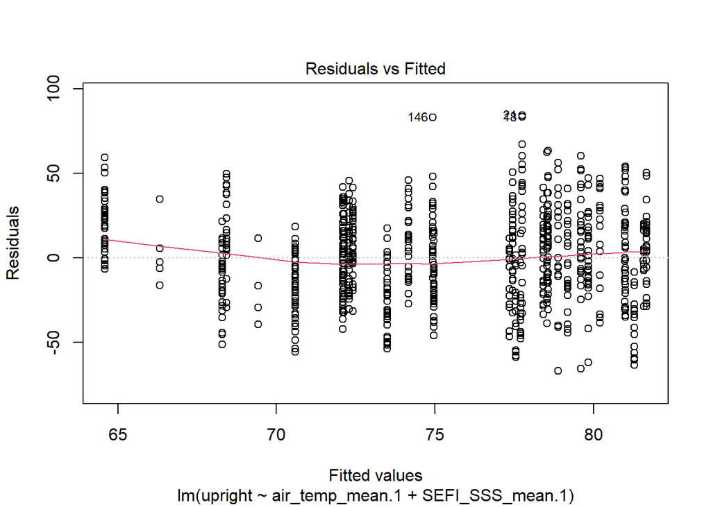

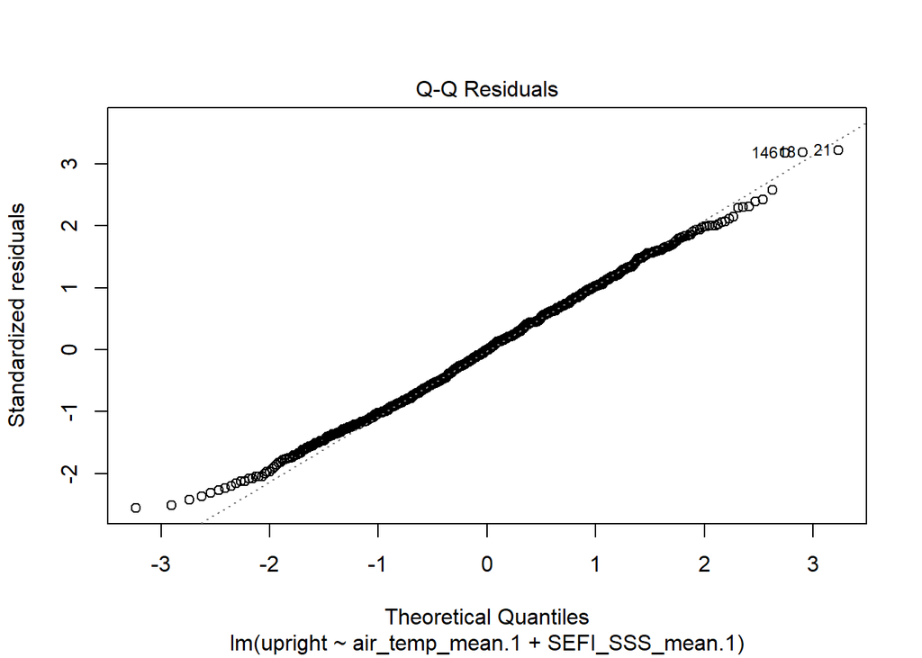

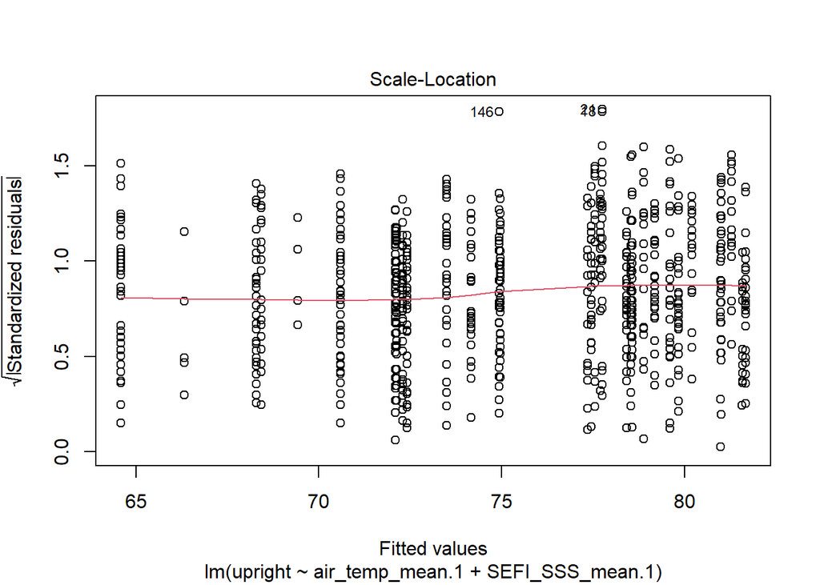

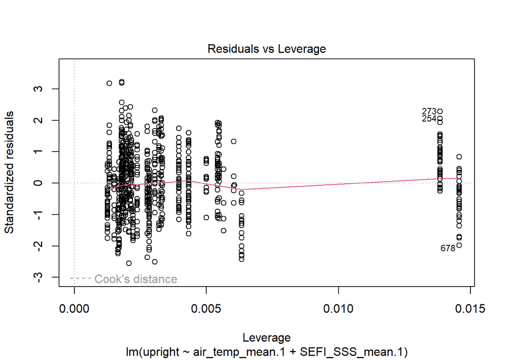

```r
plot(u2.4.1)
```

```r
u2.4.1
```

```
##
## Call:
## lm(formula = upright ~ air_temp_mean.1 + SEFI_SSS_mean.1, data = masterfile)
##
## Coefficients:
##     (Intercept)  air_temp_mean.1  SEFI_SSS_mean.1
##         -47.105            2.505            2.689
```

```r
summary(u2.4.1)
```

```
##
## Call:
## lm(formula = upright ~ air_temp_mean.1 + SEFI_SSS_mean.1, data = masterfile)
##
## Residuals:
##     Min      1Q  Median      3Q     Max
## -66.885 -19.194  -0.097  18.043  84.257
##
## Coefficients:
##                 Estimate Std. Error t value Pr(>|t|)
## (Intercept)      -47.105     40.770  -1.155  0.24828
## air_temp_mean.1    2.505      0.745   3.362  0.00081 ***
## SEFI_SSS_mean.1    2.689      1.307   2.058  0.03992 *
## ---
## Signif. codes:  0 '***' 0.001 '**' 0.01 '*' 0.05 '.' 0.1 ' ' 1
##
## Residual standard error: 26.16 on 808 degrees of freedom
## Multiple R-squared:  0.02918,    Adjusted R-squared:  0.02677
## F-statistic: 12.14 on 2 and 808 DF,  p-value: 6.381e-06
```

```r
anova(u2.4.1)
```

```
## Analysis of Variance Table
##
## Response: upright
##                  Df Sum Sq Mean Sq F value    Pr(>F)
## air_temp_mean.1   1  13715 13714.8 20.0470 8.643e-06 ***
## SEFI_SSS_mean.1   1   2897  2897.4  4.2351   0.03992 *
## Residuals       808 552780   684.1
## ---
## Signif. codes:  0 '***' 0.001 '**' 0.01 '*' 0.05 '.' 0.1 ' ' 1
```

```r
confint(u2.4.1)
```

```
##                        2.5 %    97.5 %
## (Intercept)     -127.1315865 32.922556
## air_temp_mean.1    1.0422923  3.967096
## SEFI_SSS_mean.1    0.1241734  5.253637
```

Table of model u2.4.1 with standard error

```
## `ci_method` must be one of "residual", "wald", "normal", "profile",
##   "boot", "uniroot", "betwithin" or "ml1". Using "wald" now.
```

#AIC - Q1, all upright, three-month lag

Save AICc results as a CSV

```r
write.csv(umodel3_aic, "C:/Users/Elizabeth Max/iCloudDrive/Thesis/Data/R/umodel3_aic.csv", row.names = TRUE)
```

Make a nice table of Upright model AIC rank results

```r
umodel3_table <-
  tab_df(umodel3_aic,  #models to table
         alternate.rows = TRUE,
         title = "AIC Model Ranking Results - all upright species. SEFI environmental variables lagged 3 months.",
         col.header = c( #Default headers are okay, these are better
            "Model",
            "K",
            "AIC",
            "Delta AIC",
            "AIC Wt",
            "Cum. Wt",
            "LL"
            ),
         CSS = list( #Use CSS to modify table appearance
           css.footnote = 'text-align: left; '
         ),
         footnote = "<i>K</i> = multiplier penalty term depending on the number of terms in the model.<br/>
          <i>AIC</i> = Aikaki Information Criterion (AIC); models with lower AIC values contain more information.<br/>
         <i>Delta AIC</i> = Change in AIC value from top ranked model.<br/>
         <i>AIC Wt</i> = weight of evidence for given model.</br>
         <i>Cum.Wt</i> = cumulative AIC weight.</br>
         <i>LL</i> = log-likelihood of given model.",
         show.footnote = TRUE)

print(umodel3_table)
```

Model u4.1.3 is ranked the highest. u4.1.3 <- lm(upright ~ SEFI_SST_mean.3 + air_temp_mean.3 + SEFI_SSS_mean.3 + SEFI_SST_mean.3:SEFI_SSS_mean.3, data = masterfile)

Fitting and analyzing the top ranked model

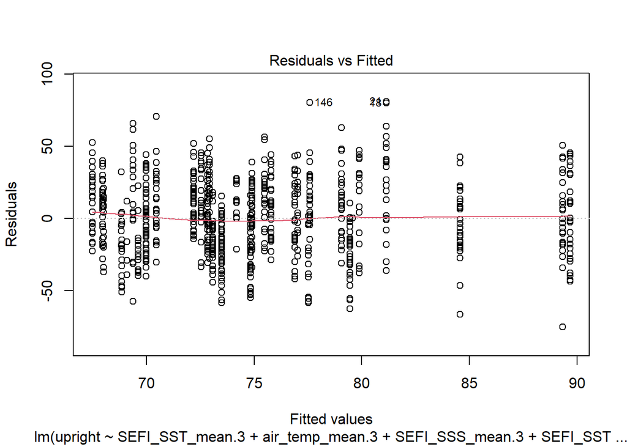

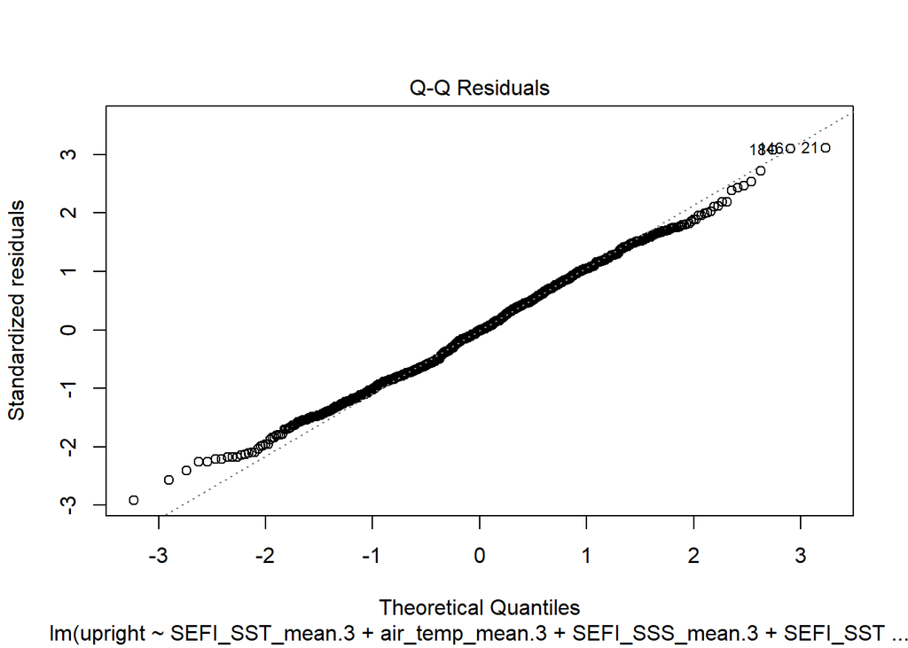

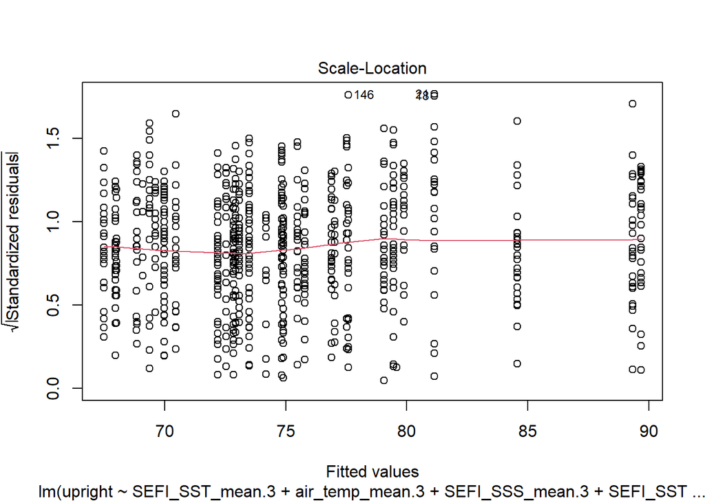

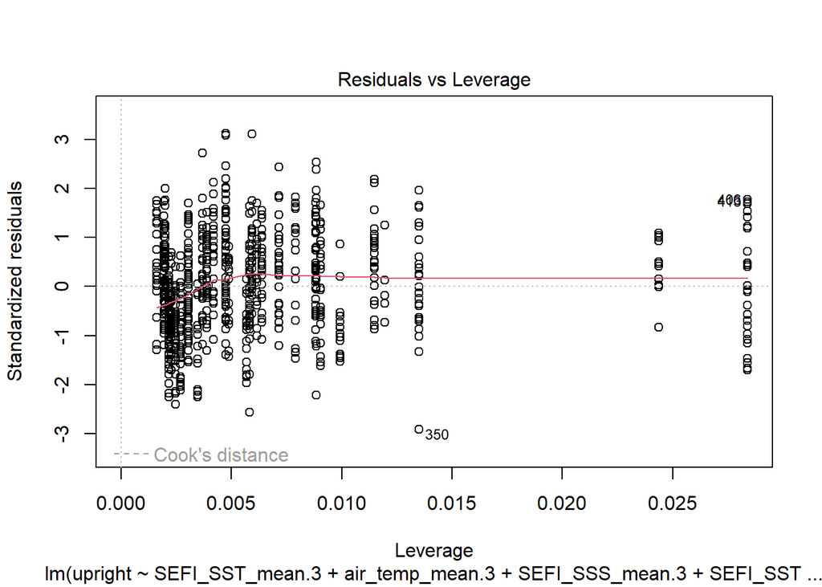

```r
plot(u4.1.3)
```

```r
u4.1.3
```

```
##
## Call:
## lm(formula = upright ~ SEFI_SST_mean.3 + air_temp_mean.3 + SEFI_SSS_mean.3 +
##     SEFI_SST_mean.3:SEFI_SSS_mean.3, data = masterfile)
##
## Coefficients:
##                     (Intercept)                  SEFI_SST_mean.3
##                       -4180.107                          388.794
##                 air_temp_mean.3                  SEFI_SSS_mean.3
##                           3.298                          126.284
## SEFI_SST_mean.3:SEFI_SSS_mean.3
##                         -11.655
```

```r
summary(u4.1.3)
```

```
##
## Call:
## lm(formula = upright ~ SEFI_SST_mean.3 + air_temp_mean.3 + SEFI_SSS_mean.3 +
##     SEFI_SST_mean.3:SEFI_SSS_mean.3, data = masterfile)
##
## Residuals:
##     Min      1Q  Median      3Q     Max
## -75.339 -19.071  -0.339  18.463  80.858
##
## Coefficients:
##                                  Estimate Std. Error t value Pr(>|t|)
## (Intercept)                     -4180.107   1520.944  -2.748  0.00612 **
## SEFI_SST_mean.3                   388.794    124.199   3.130  0.00181 **
## air_temp_mean.3                     3.298      1.022   3.227  0.00130 **
## SEFI_SSS_mean.3                   126.284     45.191   2.794  0.00532 **
## SEFI_SST_mean.3:SEFI_SSS_mean.3   -11.655      3.682  -3.166  0.00161 **
## ---
## Signif. codes:  0 '***' 0.001 '**' 0.01 '*' 0.05 '.' 0.1 ' ' 1
##
## Residual standard error: 25.98 on 806 degrees of freedom
## Multiple R-squared:  0.04442,    Adjusted R-squared:  0.03968
## F-statistic: 9.367 on 4 and 806 DF,  p-value: 2.108e-07
```

```r
anova(u4.1.3)
```

```
## Analysis of Variance Table
##
## Response: upright
##                                  Df Sum Sq Mean Sq F value    Pr(>F)
## SEFI_SST_mean.3                   1    261   261.3  0.3871 0.5340160
## air_temp_mean.3                   1   8692  8692.3 12.8763 0.0003529 ***
## SEFI_SSS_mean.3                   1   9575  9574.9 14.1838 0.0001779 ***
## SEFI_SST_mean.3:SEFI_SSS_mean.3   1   6765  6765.0 10.0213 0.0016056 **
## Residuals                       806 544099   675.1
## ---
## Signif. codes:  0 '***' 0.001 '**' 0.01 '*' 0.05 '.' 0.1 ' ' 1
```

```r
confint(u4.1.3)
```

```
##                                        2.5 %       97.5 %
## (Intercept)                     -7165.586824 -1194.627804
## SEFI_SST_mean.3                   145.002988   632.584455
## air_temp_mean.3                     1.291663     5.304086
## SEFI_SSS_mean.3                    37.578535   214.988848
## SEFI_SST_mean.3:SEFI_SSS_mean.3   -18.881500    -4.428014
```

Table of model u4.1.3 with standard error

```
## `ci_method` must be one of "residual", "wald", "normal", "profile",
##   "boot", "uniroot", "betwithin" or "ml1". Using "wald" now.
```

#AIC - Q1, upright (non-crustose) algae, one-month lag

Save AICc results as a CSV

```r
write.csv(uamodel1_aic, "C:/Users/Elizabeth Max/iCloudDrive/Thesis/Data/R/uamodel1_aic.csv", row.names = TRUE)
```

Make a nice table of Upright model AIC rank results

```r
uamodel1_table <-
  tab_df(uamodel1_aic,  #models to table
         alternate.rows = TRUE,
         title = "AIC Model Ranking Results - upright (non-crustose) algae species. Environmental variables lagged 1 month.",
         col.header = c( #Default headers are okay, these are better
            "Model",
            "K",
            "AIC",
            "Delta AIC",
            "AIC Wt",
            "Cum. Wt",
            "LL"
            ),
         CSS = list( #Use CSS to modify table appearance
           css.footnote = 'text-align: left; '
         ),
         footnote = "<i>K</i> = multiplier penalty term depending on the number of terms in the model.<br/>
          <i>AIC</i> = Aikaki Information Criterion (AIC); models with lower AIC values contain more information.<br/>
         <i>Delta AIC</i> = Change in AIC value from top ranked model.<br/>
         <i>AIC Wt</i> = weight of evidence for given model.</br>
         <i>Cum.Wt</i> = cumulative AIC weight.</br>
         <i>LL</i> = log-likelihood of given model.",
         show.footnote = TRUE)

print(uamodel1_table)
```

Model ua1.3.1 is ranked the highest. ua1.3.1 <- lm(upalgae ~ SEFI_SSS_mean.1, data = masterfile) Let’s take a closer look.

Fitting and analyzing the top ranked model

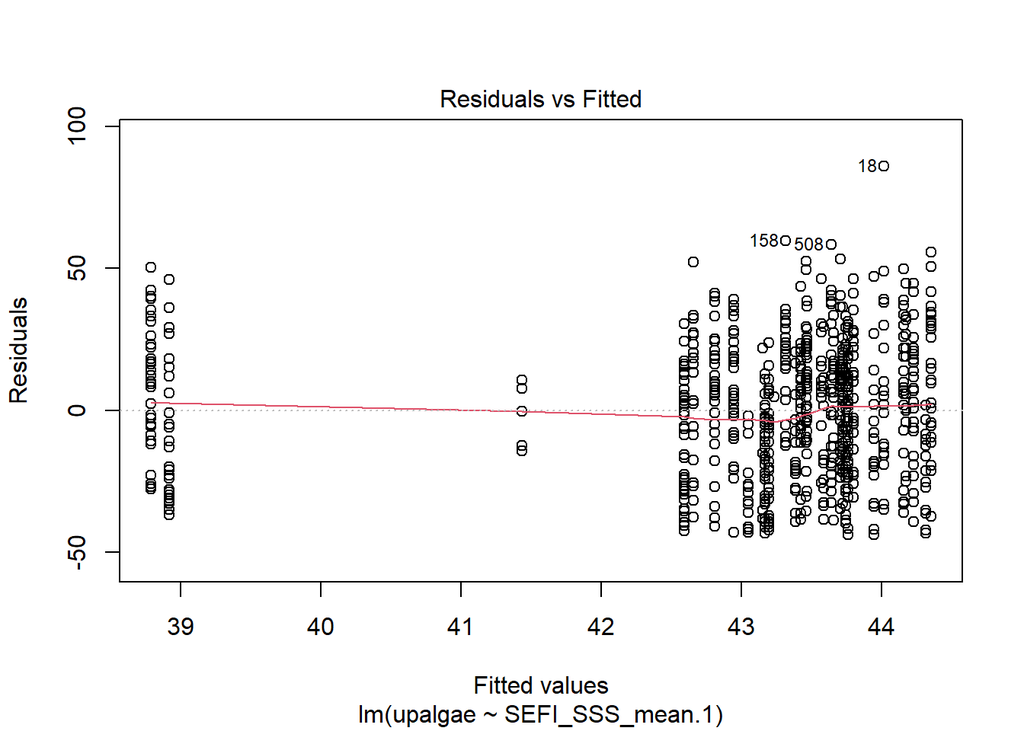

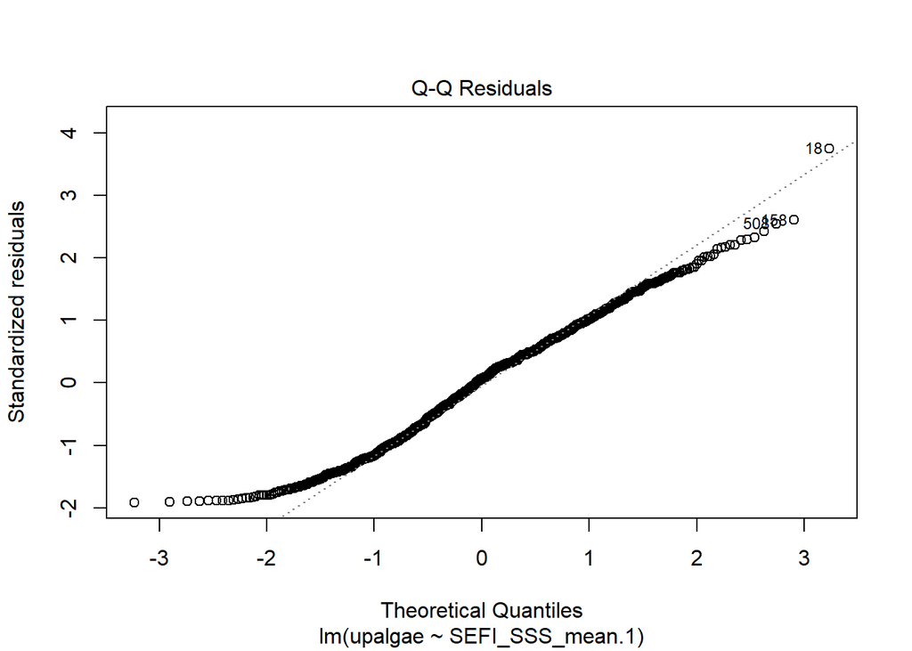

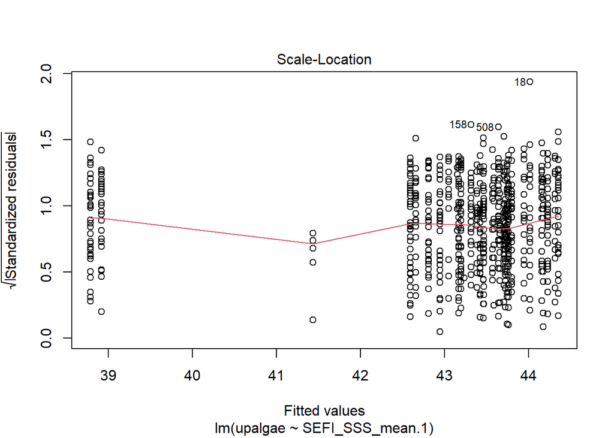

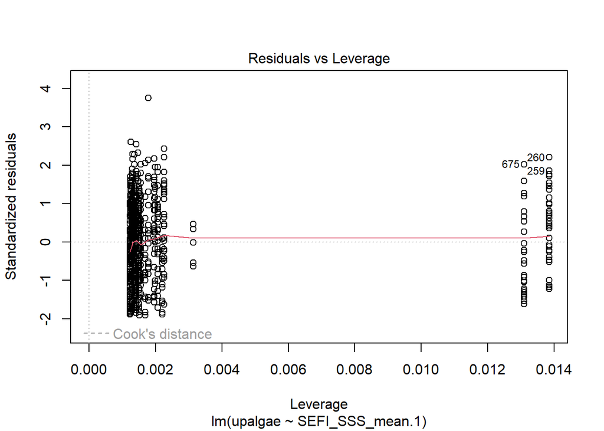

```r
plot(ua1.3.1)
```

```r
ua1.3.1
```

```
##
## Call:
## lm(formula = upalgae ~ SEFI_SSS_mean.1, data = masterfile)
##
## Coefficients:
##     (Intercept)  SEFI_SSS_mean.1
##          -16.07             1.78
```

```r
summary(ua1.3.1)
```

```
##
## Call:
## lm(formula = upalgae ~ SEFI_SSS_mean.1, data = masterfile)
##
## Residuals:
##     Min      1Q  Median      3Q     Max
## -43.944 -18.486   1.414  16.342  85.983
##
## Coefficients:
##                 Estimate Std. Error t value Pr(>|t|)
## (Intercept)       -16.07      35.27  -0.456   0.6488
## SEFI_SSS_mean.1     1.78       1.06   1.679   0.0936 .
## ---
## Signif. codes:  0 '***' 0.001 '**' 0.01 '*' 0.05 '.' 0.1 ' ' 1
##
## Residual standard error: 22.94 on 809 degrees of freedom
## Multiple R-squared:  0.003471,   Adjusted R-squared:  0.002239
## F-statistic: 2.818 on 1 and 809 DF,  p-value: 0.09362
```

```r
anova(ua1.3.1)
```

```
## Analysis of Variance Table
##
## Response: upalgae
##                  Df Sum Sq Mean Sq F value  Pr(>F)
## SEFI_SSS_mean.1   1   1483 1482.53  2.8176 0.09362 .
## Residuals       809 425666  526.16
## ---
## Signif. codes:  0 '***' 0.001 '**' 0.01 '*' 0.05 '.' 0.1 ' ' 1
```

```r
confint(ua1.3.1)
```

```
##                       2.5 %   97.5 %
## (Intercept)     -85.2920967 53.15710
## SEFI_SSS_mean.1  -0.3014362  3.86069
```

Table of model ua1.3.1 with standard error

```
## `ci_method` must be one of "residual", "wald", "normal", "profile",
##   "boot", "uniroot", "betwithin" or "ml1". Using "wald" now.
```

#AIC - Q1, upright (non-crustose) algae, three-month lag

Save AICc results as a CSV

```r
write.csv(uamodel3_aic, "C:/Users/Elizabeth Max/iCloudDrive/Thesis/Data/R/uamodel3_aic.csv", row.names = TRUE)
```

Make a nice table of Upright model AIC rank results

```r
uamodel3_table <-
  tab_df(uamodel3_aic,  #models to table
         alternate.rows = TRUE,
         title = "AIC Model Ranking Results - upright (non-crustose) algae species. Environmental variables lagged 3 months.",
         col.header = c( #Default headers are okay, these are better
            "Model",
            "K",
            "AIC",
            "Delta AIC",
            "AIC Wt",
            "Cum. Wt",
            "LL"
            ),
         CSS = list( #Use CSS to modify table appearance
           css.footnote = 'text-align: left; '
         ),
         footnote = "<i>K</i> = multiplier penalty term depending on the number of terms in the model.<br/>
          <i>AIC</i> = Aikaki Information Criterion (AIC); models with lower AIC values contain more information.<br/>
         <i>Delta AIC</i> = Change in AIC value from top ranked model.<br/>
         <i>AIC Wt</i> = weight of evidence for given model.</br>
         <i>Cum.Wt</i> = cumulative AIC weight.</br>
         <i>LL</i> = log-likelihood of given model.",
         show.footnote = TRUE)

print(uamodel3_table)
```

Model ua3.3.3 is ranked the highest. ua3.3.3 <- lm(upalgae ~ SEFI_SST_mean.3 + SEFI_SSS_mean.3 + SEFI_SST_mean.3:SEFI_SSS_mean.3, data = masterfile) Let’s take a closer look.

Fitting and analyzing the top ranked model

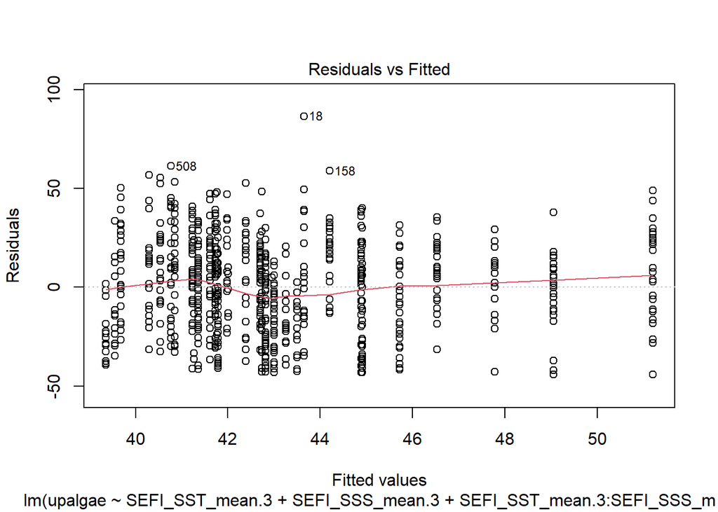

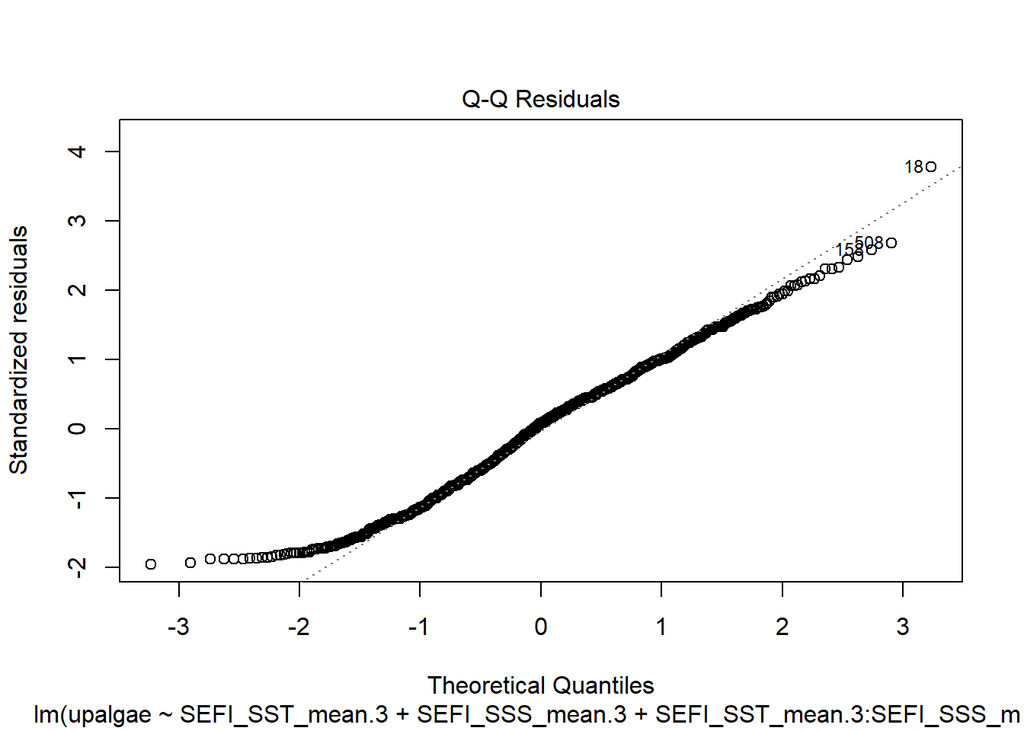

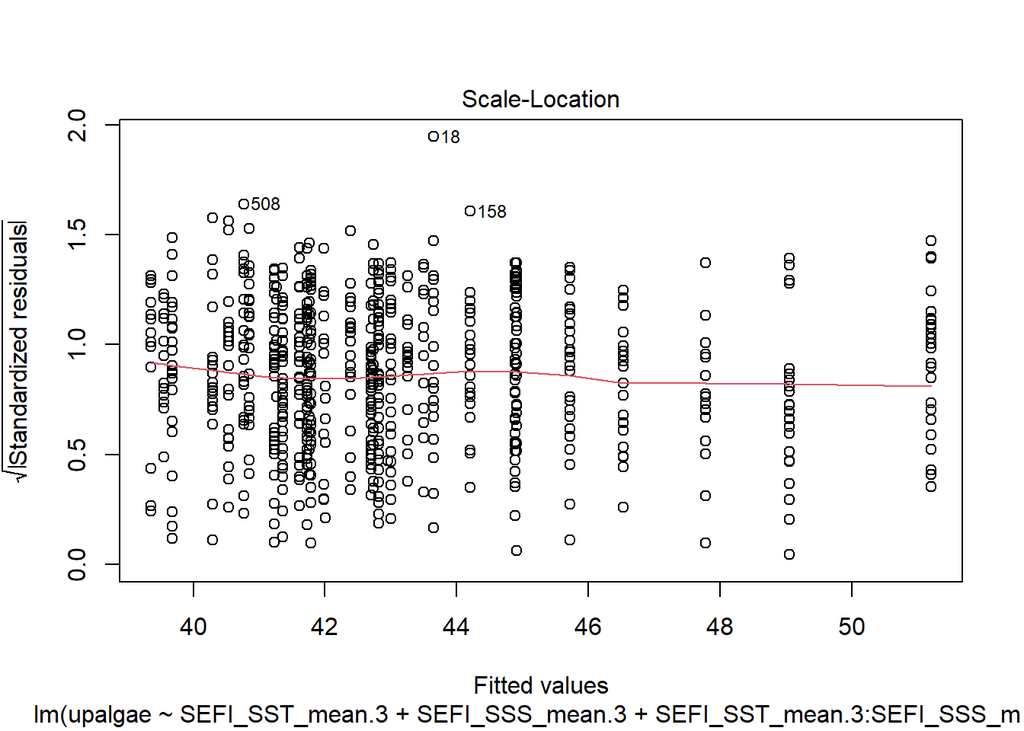

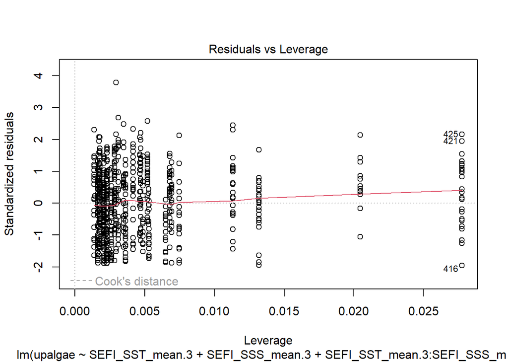

```r
plot(ua3.3.3)
```

```r
ua3.3.3
```

```
##
## Call:
## lm(formula = upalgae ~ SEFI_SST_mean.3 + SEFI_SSS_mean.3 + SEFI_SST_mean.3:SEFI_SSS_mean.3,
##     data = masterfile)
##
## Coefficients:
##                     (Intercept)                  SEFI_SST_mean.3
##                       -3883.986                          332.780
##                 SEFI_SSS_mean.3  SEFI_SST_mean.3:SEFI_SSS_mean.3
##                         116.691                           -9.893
```

```r
summary(ua3.3.3)
```

```
##
## Call:
## lm(formula = upalgae ~ SEFI_SST_mean.3 + SEFI_SSS_mean.3 + SEFI_SST_mean.3:SEFI_SSS_mean.3,
##     data = masterfile)
##
## Residuals:
##     Min      1Q  Median      3Q     Max
## -44.197 -17.725   1.708  16.035  86.356
##
## Coefficients:
##                                  Estimate Std. Error t value Pr(>|t|)
## (Intercept)                     -3883.986   1257.759  -3.088  0.00208 **
## SEFI_SST_mean.3                   332.780    103.279   3.222  0.00132 **
## SEFI_SSS_mean.3                   116.691     37.320   3.127  0.00183 **
## SEFI_SST_mean.3:SEFI_SSS_mean.3    -9.893      3.067  -3.226  0.00131 **
## ---
## Signif. codes:  0 '***' 0.001 '**' 0.01 '*' 0.05 '.' 0.1 ' ' 1
##
## Residual standard error: 22.85 on 807 degrees of freedom
## Multiple R-squared:  0.01365,    Adjusted R-squared:  0.009983
## F-statistic: 3.723 on 3 and 807 DF,  p-value: 0.01121
```

```r
anova(ua3.3.3)
```

```
## Analysis of Variance Table
##
## Response: upalgae
##                                  Df Sum Sq Mean Sq F value   Pr(>F)
## SEFI_SST_mean.3                   1      6     6.2  0.0119 0.913196
## SEFI_SSS_mean.3                   1    391   390.7  0.7484 0.387240
## SEFI_SST_mean.3:SEFI_SSS_mean.3   1   5433  5433.4 10.4073 0.001306 **
## Residuals                       807 421318   522.1
## ---
## Signif. codes:  0 '***' 0.001 '**' 0.01 '*' 0.05 '.' 0.1 ' ' 1
```

```r
confint(ua3.3.3)
```

```
##                                       2.5 %       97.5 %
## (Intercept)                     -6352.84992 -1415.121100
## SEFI_SST_mean.3                   130.05377   535.506570
## SEFI_SSS_mean.3                    43.43566   189.946800
## SEFI_SST_mean.3:SEFI_SSS_mean.3   -15.91277    -3.873584
```

Table of model ua3.3.3 with standard error SEFI_SST_mean.3 + SEFI_SSS_mean.3 + SEFI_SST_mean.3:SEFI_SSS_mean.3

```
## `ci_method` must be one of "residual", "wald", "normal", "profile",
##   "boot", "uniroot", "betwithin" or "ml1". Using "wald" now.
```

#AIC - Q1, upright (non-crustose) invertebrates, one-month lag

Save AICc results as a CSV

```r
write.csv(uimodel1_aic, "C:/Users/Elizabeth Max/iCloudDrive/Thesis/Data/R/uimodel1_aic.csv", row.names = TRUE)
```

Make a nice table of Upright model AIC rank results

```r
uimodel1_table <-
  tab_df(uimodel1_aic,  #models to table
         alternate.rows = TRUE,
         title = "AIC Model Ranking Results - upright (non-crustose) invertebrate species. Environmental variables lagged 1 month.",
         col.header = c( #Default headers are okay, these are better
            "Model",
            "K",
            "AIC",
            "Delta AIC",
            "AIC Wt",
            "Cum. Wt",
            "LL"
            ),
         CSS = list( #Use CSS to modify table appearance
           css.footnote = 'text-align: left; '
         ),
         footnote = "<i>K</i> = multiplier penalty term depending on the number of terms in the model.<br/>
          <i>AIC</i> = Aikaki Information Criterion (AIC); models with lower AIC values contain more information.<br/>
         <i>Delta AIC</i> = Change in AIC value from top ranked model.<br/>
         <i>AIC Wt</i> = weight of evidence for given model.</br>
         <i>Cum.Wt</i> = cumulative AIC weight.</br>
         <i>LL</i> = log-likelihood of given model.",
         show.footnote = TRUE)

print(uimodel1_table)
```

Model ui1.4.1 is ranked the highest. ui1.4.1 <- lm(upinverts ~ SEFI_SST_mean.1:SEFI_SSS_mean.1, data = masterfile) Let’s take a closer look.

Fitting and analyzing the top ranked model

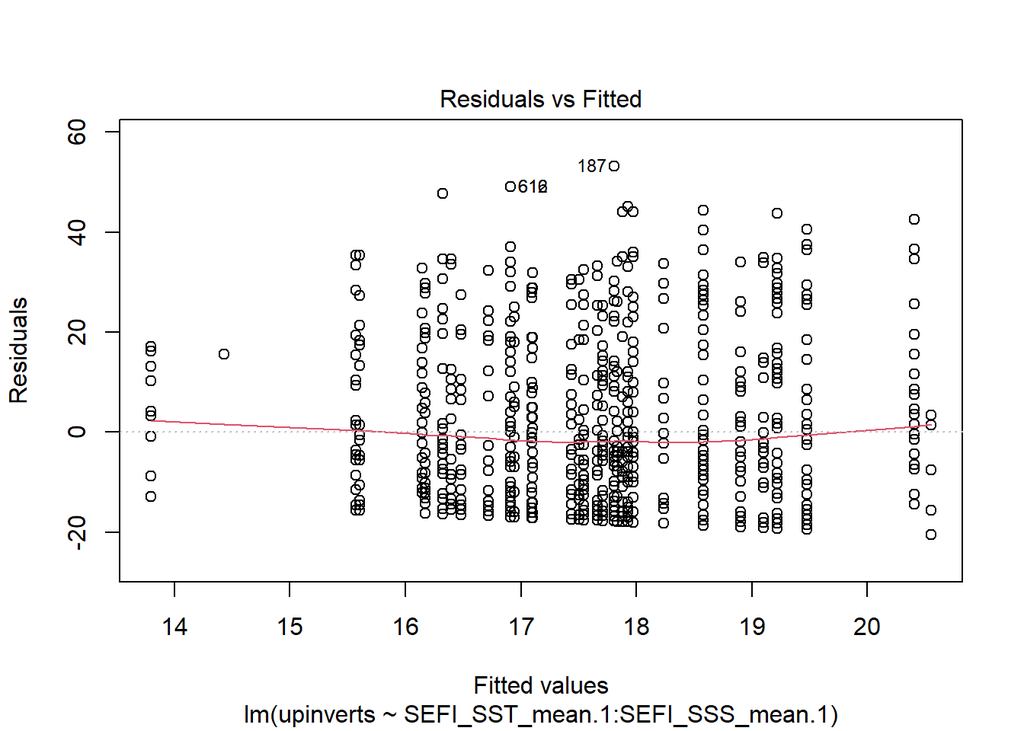

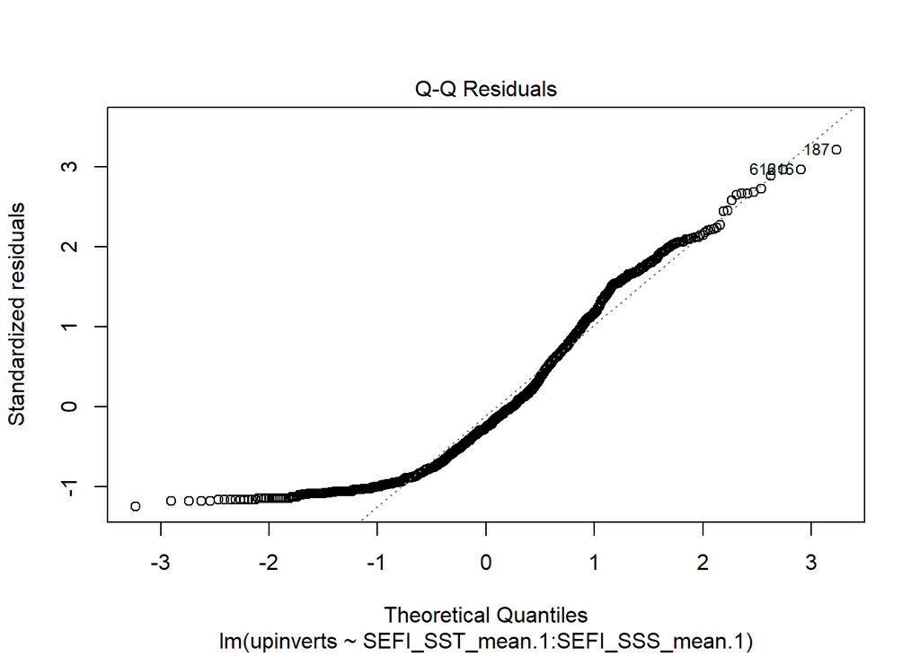

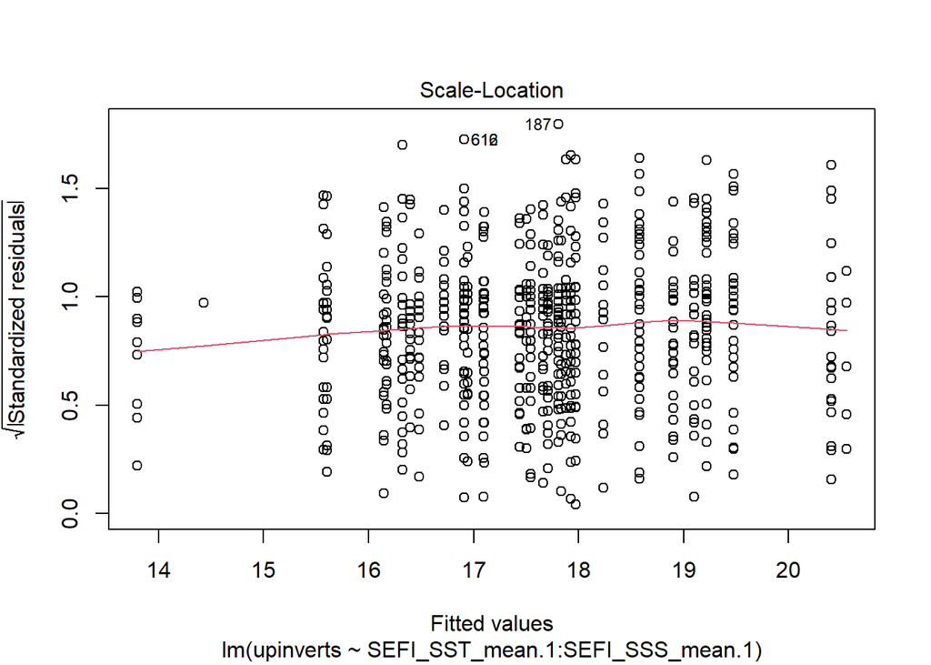

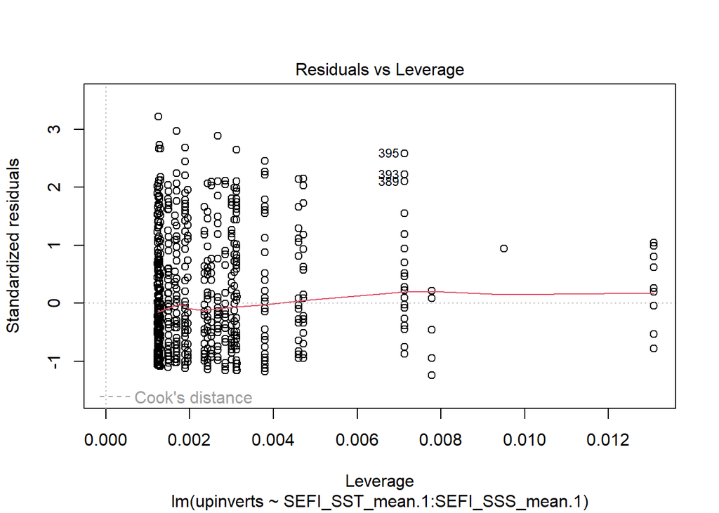

```r
plot(ui1.4.1)
```

```r
ui1.4.1
```

```
##
## Call:
## lm(formula = upinverts ~ SEFI_SST_mean.1:SEFI_SSS_mean.1, data = masterfile)
##
## Coefficients:
##                     (Intercept)  SEFI_SST_mean.1:SEFI_SSS_mean.1
##                        35.52678                         -0.04276
```

```r
summary(ui1.4.1)
```

```
##
## Call:
## lm(formula = upinverts ~ SEFI_SST_mean.1:SEFI_SSS_mean.1, data = masterfile)
##
## Residuals:
##     Min      1Q  Median      3Q     Max
## -20.550 -14.473  -4.217  10.840  53.193
##
## Coefficients:
##                                 Estimate Std. Error t value Pr(>|t|)
## (Intercept)                     35.52678    8.31564   4.272 2.16e-05 ***
## SEFI_SST_mean.1:SEFI_SSS_mean.1 -0.04276    0.01987  -2.153   0.0317 *
## ---
## Signif. codes:  0 '***' 0.001 '**' 0.01 '*' 0.05 '.' 0.1 ' ' 1
##
## Residual standard error: 16.53 on 809 degrees of freedom
## Multiple R-squared:  0.005695,   Adjusted R-squared:  0.004466
## F-statistic: 4.633 on 1 and 809 DF,  p-value: 0.03165
```

```r
anova(ui1.4.1)
```

```
## Analysis of Variance Table
##
## Response: upinverts
##                                  Df Sum Sq Mean Sq F value  Pr(>F)
## SEFI_SST_mean.1:SEFI_SSS_mean.1   1   1267 1266.59  4.6334 0.03165 *
## Residuals                       809 221149  273.36
## ---
## Signif. codes:  0 '***' 0.001 '**' 0.01 '*' 0.05 '.' 0.1 ' ' 1
```

```r
confint(ui1.4.1)
```

```
##                                       2.5 %       97.5 %
## (Intercept)                     19.20400420 51.849559849
## SEFI_SST_mean.1:SEFI_SSS_mean.1 -0.08175591 -0.003767157
```

Table of model ui1.4.1 with standard error

```
## `ci_method` must be one of "residual", "wald", "normal", "profile",
##   "boot", "uniroot", "betwithin" or "ml1". Using "wald" now.
```

#AIC - Q1, upright (non-crustose) invertebrates, three-month lag

Save AICc results as a CSV

```r
write.csv(uimodel3_aic, "C:/Users/Elizabeth Max/iCloudDrive/Thesis/Data/R/uimodel3_aic.csv", row.names = TRUE)
```

Make a nice table of Upright model AIC rank results

```r
uimodel3_table <-
  tab_df(uimodel3_aic,  #models to table
         alternate.rows = TRUE,
         title = "AIC Model Ranking Results - upright (non-crustose) invertebrate species. Environmental variables lagged 3 months.",
         col.header = c( #Default headers are okay, these are better
            "Model",
            "K",
            "AIC",
            "Delta AIC",
            "AIC Wt",
            "Cum. Wt",
            "LL"
            ),
         CSS = list( #Use CSS to modify table appearance
           css.footnote = 'text-align: left; '
         ),
         footnote = "<i>K</i> = multiplier penalty term depending on the number of terms in the model.<br/>
          <i>AIC</i> = Aikaki Information Criterion (AIC); models with lower AIC values contain more information.<br/>
         <i>Delta AIC</i> = Change in AIC value from top ranked model.<br/>
         <i>AIC Wt</i> = weight of evidence for given model.</br>
         <i>Cum.Wt</i> = cumulative AIC weight.</br>
         <i>LL</i> = log-likelihood of given model.",
         show.footnote = TRUE)

print(uimodel3_table)
```

Model ui1.4.3 is ranked the highest. ui1.4.3 <- lm(upinverts ~ SEFI_SST_mean.3:SEFI_SSS_mean.3, data = masterfile) Let’s take a closer look.

Fitting and analyzing the top ranked model

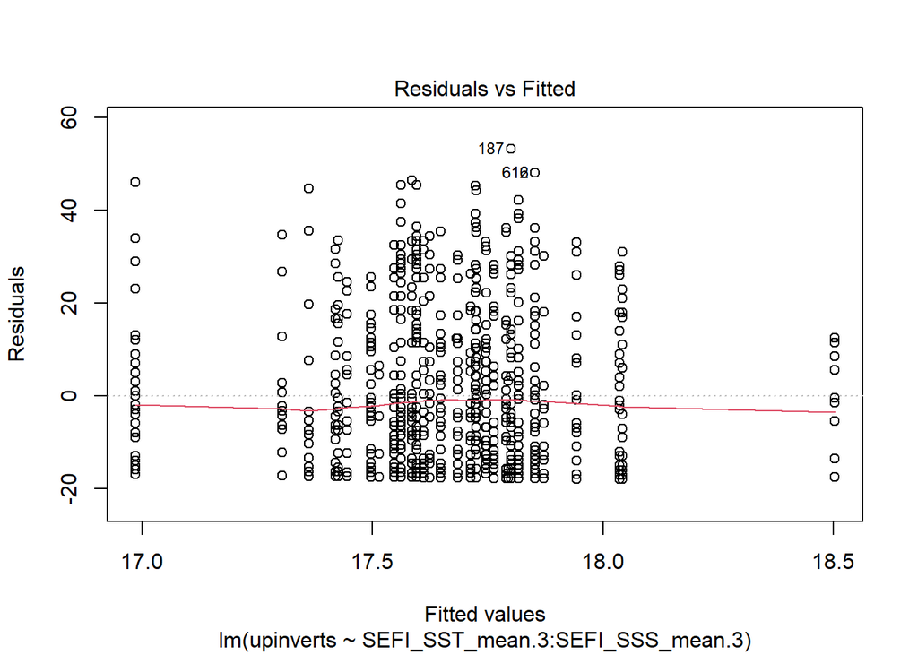

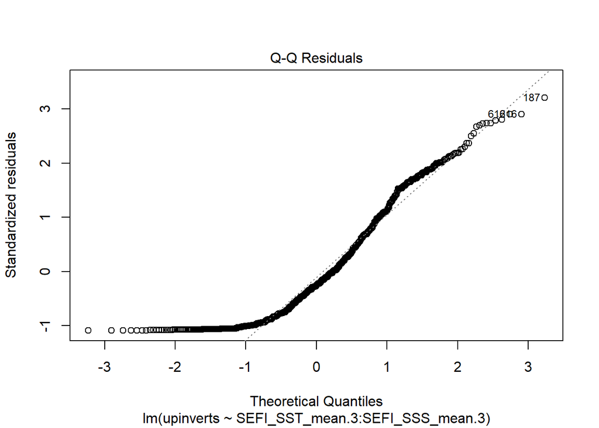

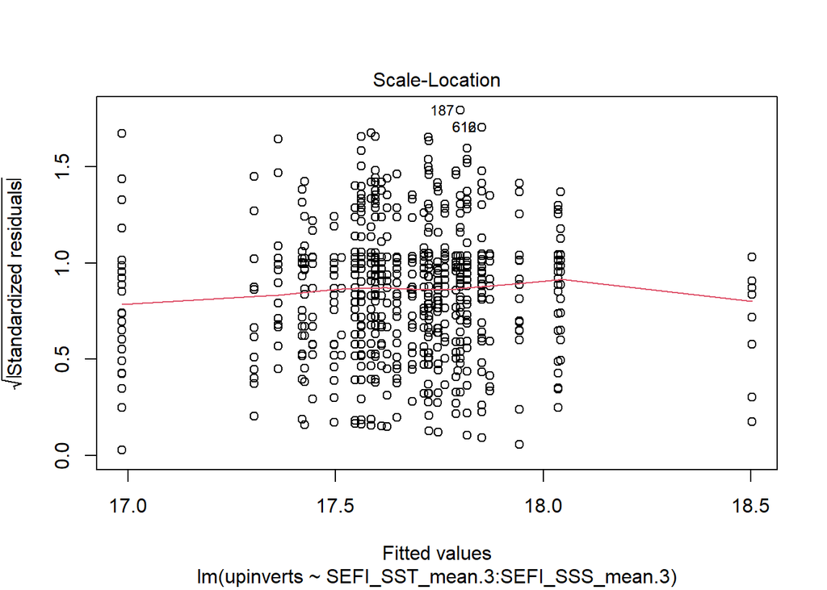

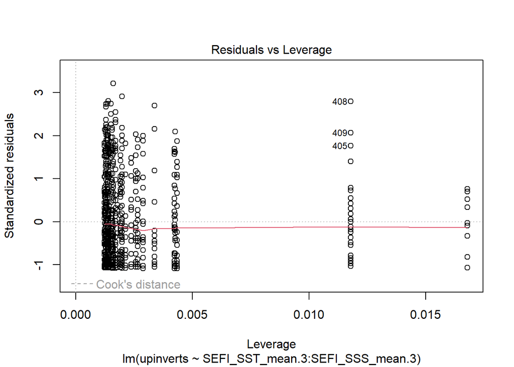

```r
plot(ui1.4.3)
```

```r
ui1.4.3
```

```
##
## Call:
## lm(formula = upinverts ~ SEFI_SST_mean.3:SEFI_SSS_mean.3, data = masterfile)
##
## Coefficients:
##                     (Intercept)  SEFI_SST_mean.3:SEFI_SSS_mean.3
##                       14.722280                         0.006997
```

```r
summary(ui1.4.3)
```

```
##
## Call:
## lm(formula = upinverts ~ SEFI_SST_mean.3:SEFI_SSS_mean.3, data = masterfile)
##
## Residuals:
##     Min      1Q  Median      3Q     Max
## -18.043 -14.667  -4.419  11.174  53.200
##
## Coefficients:
##                                  Estimate Std. Error t value Pr(>|t|)
## (Intercept)                     14.722280   7.350554   2.003   0.0455 *
## SEFI_SST_mean.3:SEFI_SSS_mean.3  0.006997   0.017388   0.402   0.6875
## ---
## Signif. codes:  0 '***' 0.001 '**' 0.01 '*' 0.05 '.' 0.1 ' ' 1
##
## Residual standard error: 16.58 on 809 degrees of freedom
## Multiple R-squared:  0.0002001,  Adjusted R-squared:  -0.001036
## F-statistic: 0.1619 on 1 and 809 DF,  p-value: 0.6875
```

```r
anova(ui1.4.3)
```

```
## Analysis of Variance Table
##
## Response: upinverts
##                                  Df Sum Sq Mean Sq F value Pr(>F)
## SEFI_SST_mean.3:SEFI_SSS_mean.3   1     45  44.506  0.1619 0.6875
## Residuals                       809 222371 274.871
```

```r
confint(ui1.4.3)
```

```
##                                       2.5 %     97.5 %
## (Intercept)                      0.29387252 29.1506875
## SEFI_SST_mean.3:SEFI_SSS_mean.3 -0.02713345  0.0411266
```

Table of model ui1.4.3 with standard error

```
## `ci_method` must be one of "residual", "wald", "normal", "profile",
##   "boot", "uniroot", "betwithin" or "ml1". Using "wald" now.
```

#AIC - Q1, all crusting species, one-month lag

Save AICc results as a CSV

```r
write.csv(cmodel1_aic, "C:/Users/Elizabeth Max/iCloudDrive/Thesis/Data/R/cmodel1_aic.csv", row.names = TRUE)
```

Make a nice table of Crusting model AIC rank results

```r
cmodel1_table <-
  tab_df(cmodel1_aic,  #models to table
         alternate.rows = TRUE,
         title = "AIC Model Ranking Results - all crusting species. Environmental variables lagged 1 month.",
         show.footnote = TRUE)

print(cmodel1_table)
```

Model c2.4.1 is ranked the highest. c2.4.1 <- lm(crusting ~ air_temp_mean.1 + SEFI_SSS_mean.1, data = masterfile) Let’s take a closer look.

Fitting and analyzing the top ranked model

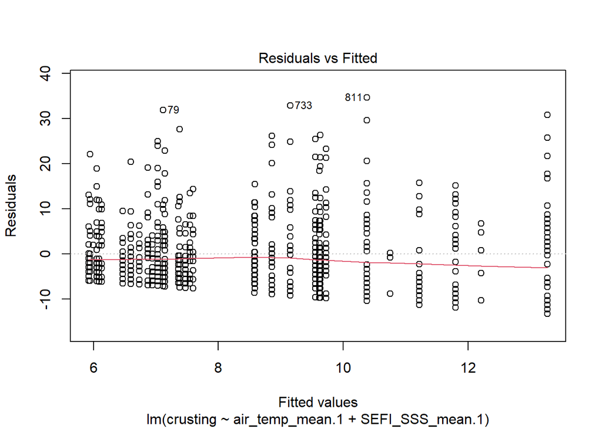

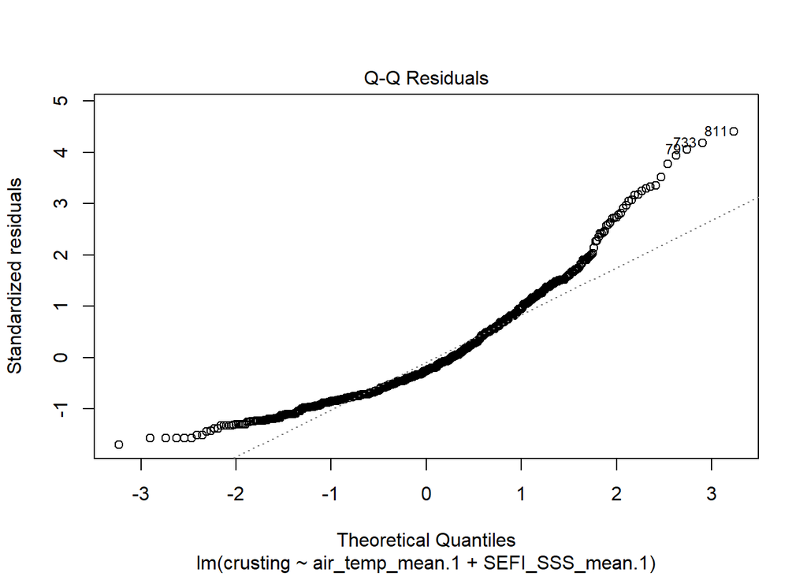

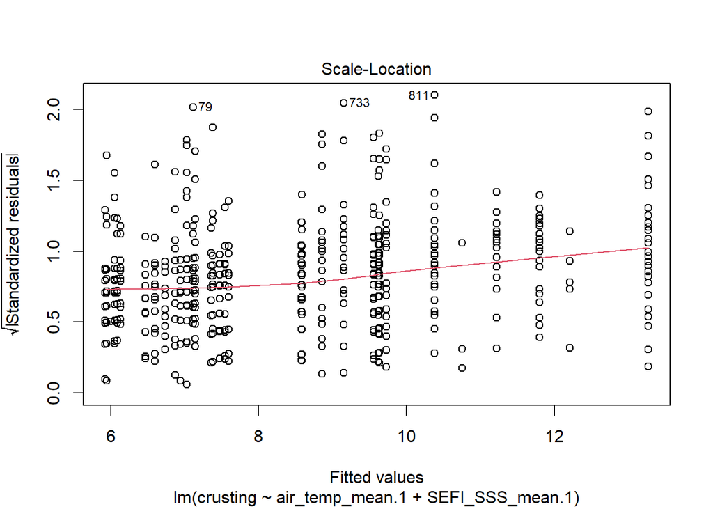

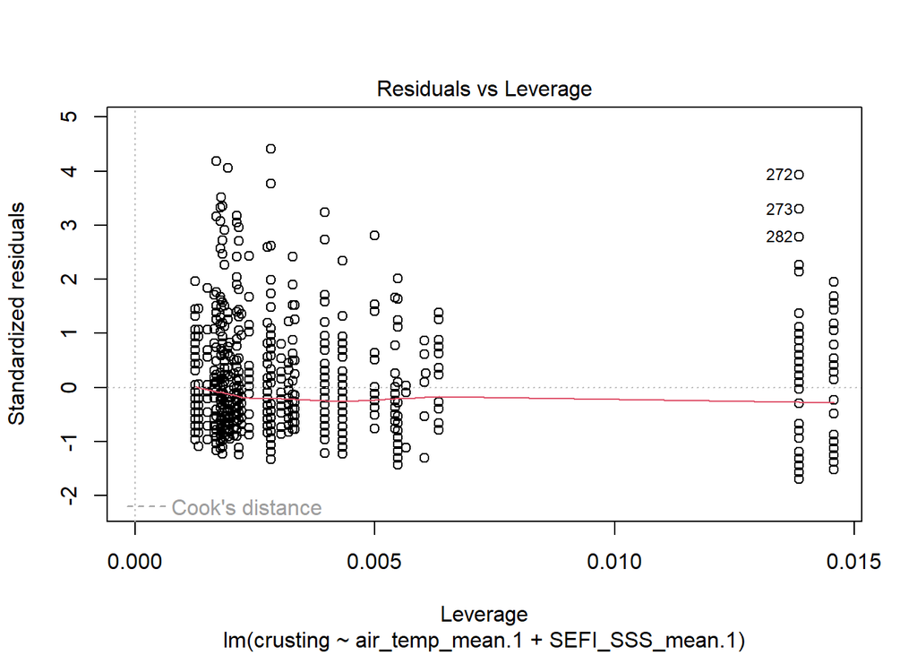

```r
plot(c2.4.1)
```

```r
c2.4.1
```

```
##
## Call:
## lm(formula = crusting ~ air_temp_mean.1 + SEFI_SSS_mean.1, data = masterfile)
##
## Coefficients:
##     (Intercept)  air_temp_mean.1  SEFI_SSS_mean.1
##         64.7854          -0.9794          -1.3058
```

```r
summary(c2.4.1)
```

```
##
## Call:
## lm(formula = crusting ~ air_temp_mean.1 + SEFI_SSS_mean.1, data = masterfile)
##
## Residuals:
##     Min      1Q  Median      3Q     Max
## -13.270  -5.635  -2.055   4.128  34.620
##
## Coefficients:
##                 Estimate Std. Error t value Pr(>|t|)
## (Intercept)      64.7854    12.2538   5.287 1.60e-07 ***
## air_temp_mean.1  -0.9794     0.2239  -4.374 1.38e-05 ***
## SEFI_SSS_mean.1  -1.3058     0.3927  -3.325 0.000924 ***
## ---
## Signif. codes:  0 '***' 0.001 '**' 0.01 '*' 0.05 '.' 0.1 ' ' 1
##
## Residual standard error: 7.861 on 808 degrees of freedom
## Multiple R-squared:  0.05624,    Adjusted R-squared:  0.0539
## F-statistic: 24.07 on 2 and 808 DF,  p-value: 6.983e-11
```

```r
anova(c2.4.1)
```

```
## Analysis of Variance Table
##
## Response: crusting
##                  Df Sum Sq Mean Sq F value    Pr(>F)
## air_temp_mean.1   1   2292 2292.48  37.093  1.74e-09 ***
## SEFI_SSS_mean.1   1    683  683.33  11.057 0.0009236 ***
## Residuals       808  49937   61.80
## ---
## Signif. codes:  0 '***' 0.001 '**' 0.01 '*' 0.05 '.' 0.1 ' ' 1
```

```r
confint(c2.4.1)
```

```
##                     2.5 %     97.5 %
## (Intercept)     40.732315 88.8385236
## air_temp_mean.1 -1.418902 -0.5398173
## SEFI_SSS_mean.1 -2.076694 -0.5349721
```

Table of model c2.4.1 with standard error

```
## `ci_method` must be one of "residual", "wald", "normal", "profile",
##   "boot", "uniroot", "betwithin" or "ml1". Using "wald" now.
```

#Plot one of the top ranked regression models plugged into AIC

```r
# Load the necessary library for plotting
library(ggplot2)

# Create a scatter plot of SEFI_SSS_mean.1 vs upalgae with the regression line
sampleregression <- ggplot(masterfile, aes(x = SEFI_SSS_mean.1, y = upalgae)) +
  geom_point(color = "blue", alpha = 0.6) +  # Scatter plot of raw data
  geom_smooth(method = "lm", se = FALSE, color = "red") +  # Add the fitted regression line
  labs(x = "Sea Surface Salinity", y = "Algal Cover",
       title = "Effect of Sea Surface Salinity on Algal Cover (Linear Regression)") +
  theme_minimal() +
  annotate("text", x = 34.5, y = 50, label = paste(round(summary(ua1.3.1)$r.squared, 3)), size = 5, color = "red")  # Annotate R-squared value
```

#with shaded confidence interval

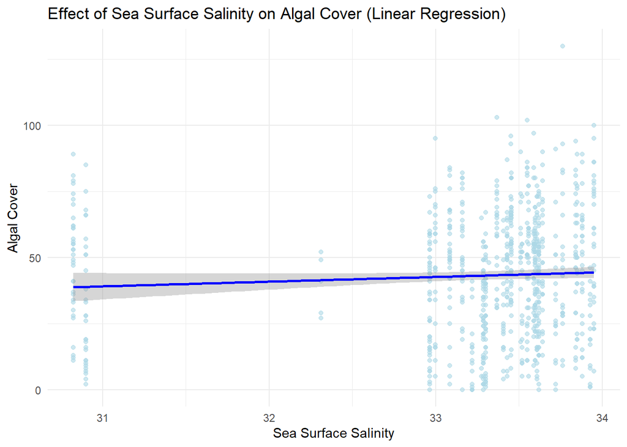

```r
# Load necessary library
library(ggplot2)

# Scatter plot with regression line and shaded confidence interval
simpreg <- ggplot(masterfile, aes(x = SEFI_SSS_mean.1, y = upalgae)) +
  geom_point(color = "lightblue", alpha = 0.6) +  # Scatter plot with light blue points
  geom_smooth(method = "lm", se = TRUE, color = "blue") +  # Linear regression line with shaded confidence interval
  labs(x = "Sea Surface Salinity", y = "Algal Cover",
       title = "Effect of Sea Surface Salinity on Algal Cover (Linear Regression)") +
  theme_minimal()
plot(simpreg)
```